# ARG - Caracteristicas genrales e imputacion

Serie del índice Ag Barometer ARG

Autor/a

Patricia Analía Nesci

# 1 Caracteristicas de los indices (sin imputar)

## 1.1 Ag Barometer

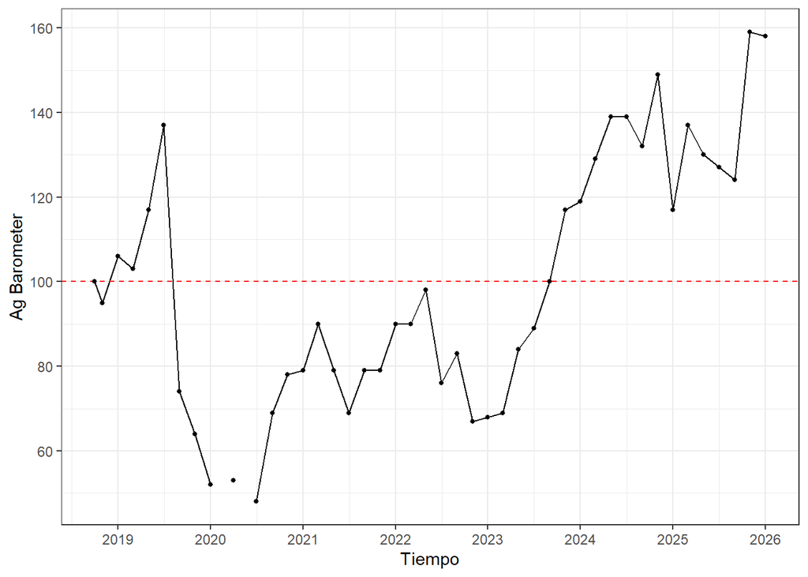

### 1.1.1 ACF de dif1

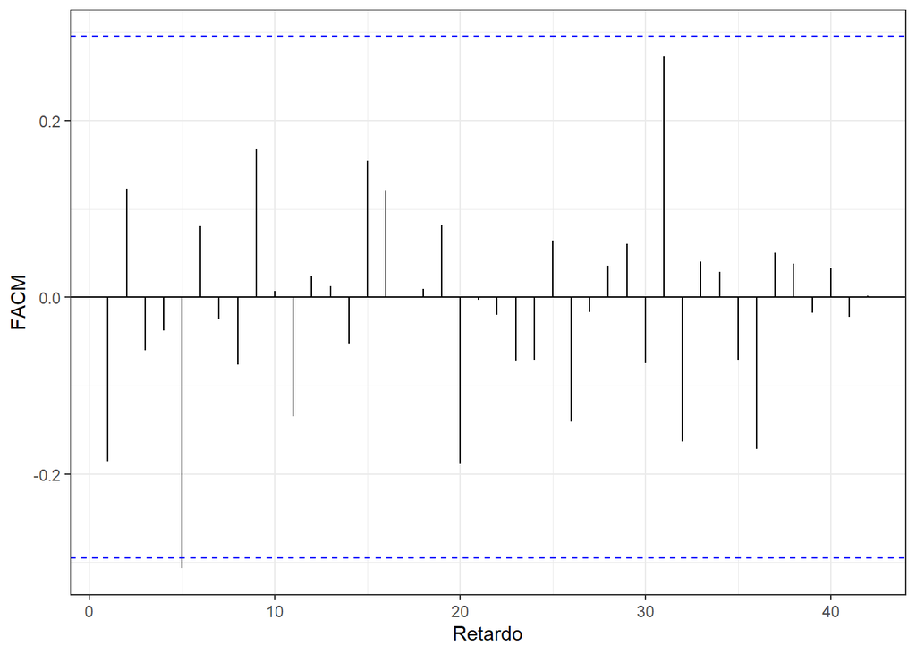

Test Ljung-Box

$H_0) \quad \rho_1 = \dots = \rho_{30} = 0$ ,

$\rho_k:$ coeficiente de autocorrelación de la primer diferencia

```
    Box-Ljung test

data:  pull(drop_na(mutate(tidyr::fill(fill_gaps(d), `Ag Barometer`, .direction = "down"), dif1 = difference(`Ag Barometer`)), dif1), dif1)
X-squared = 22.503, df = 30, p-value = 0.8351
```

### 1.1.2 PACF de dif1

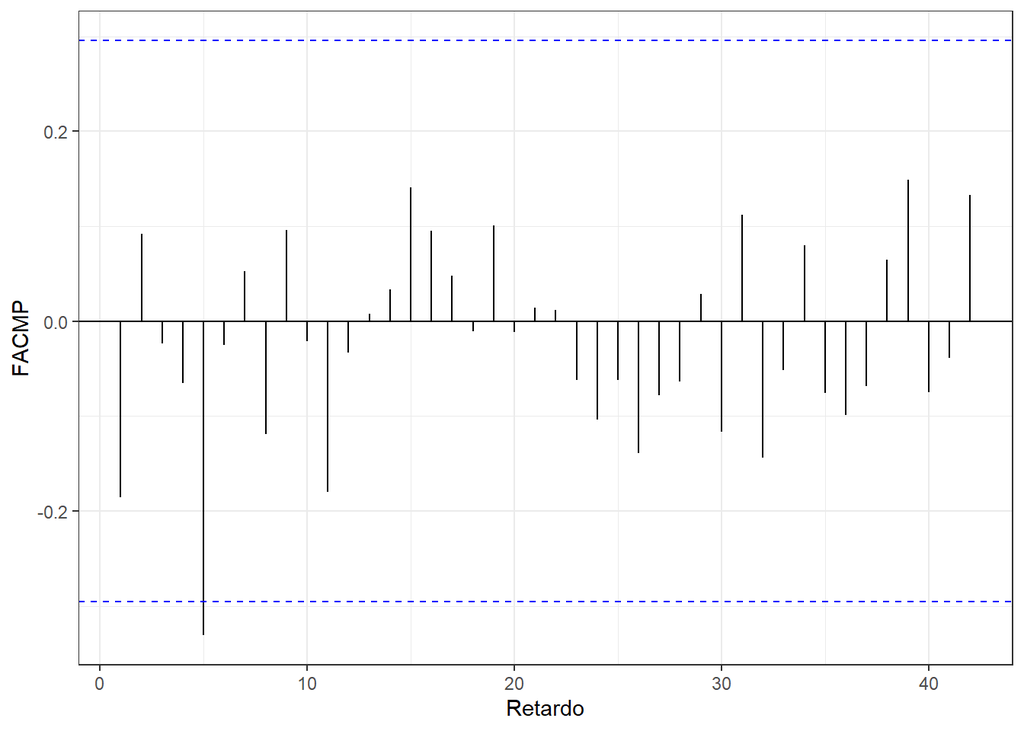

## 1.2 Condiciones Presentes

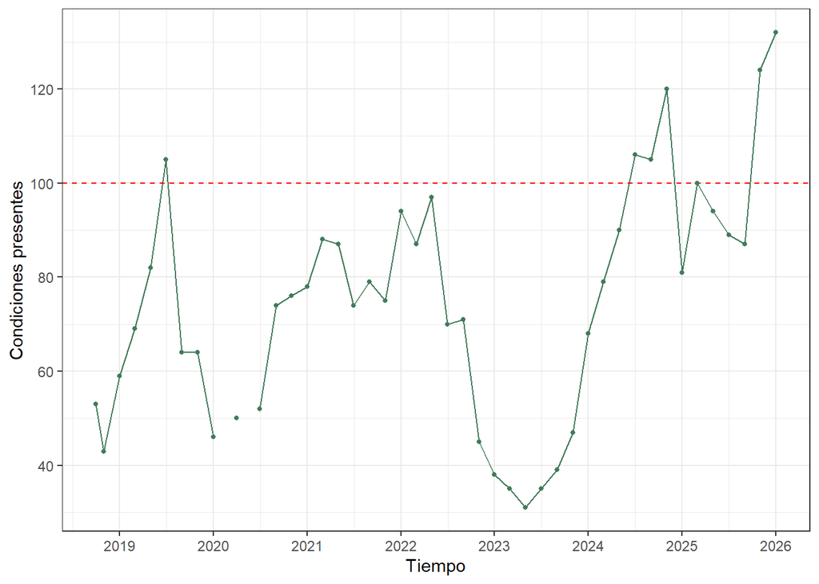

### 1.2.1 ACF de dif1

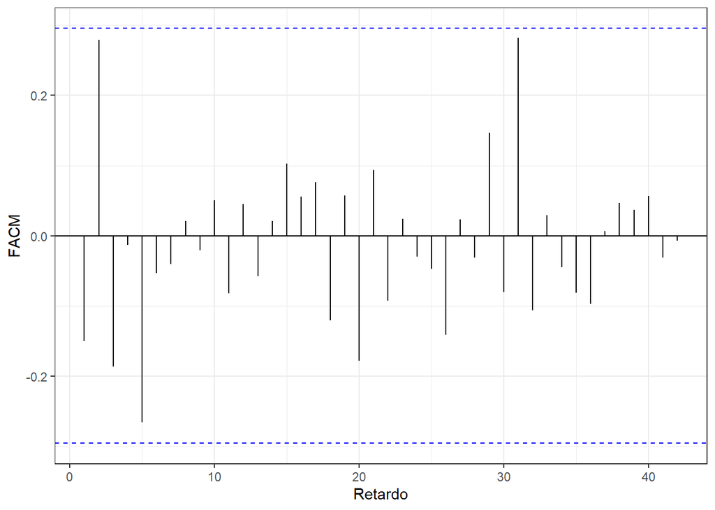

Test Ljung-Box

$H_0) \quad \rho_1 = \dots = \rho_{30} = 0$ ,

$\rho_k:$ coeficiente de autocorrelación de la primer diferencia

```
    Box-Ljung test

data:  pull(drop_na(mutate(tidyr::fill(fill_gaps(d), `Condiciones presentes`, .direction = "down"), dif1 = difference(`Condiciones presentes`)), dif1), dif1)
X-squared = 24.956, df = 30, p-value = 0.7272
```

### 1.2.2 PACF de dif1

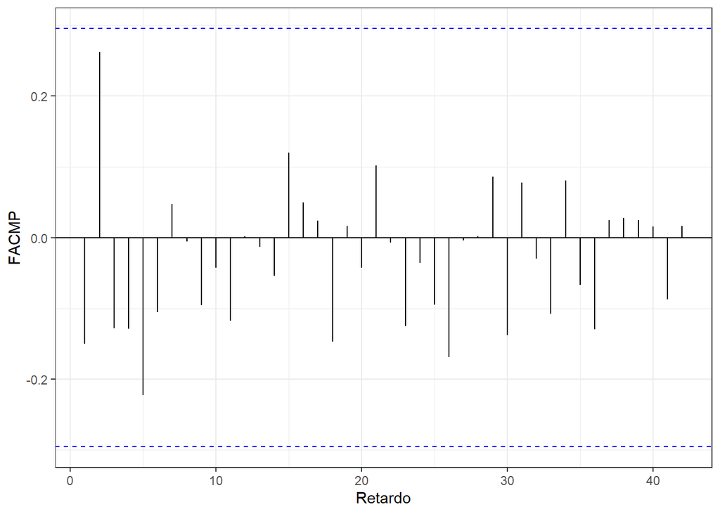

## 1.3 Expectativas Futuras

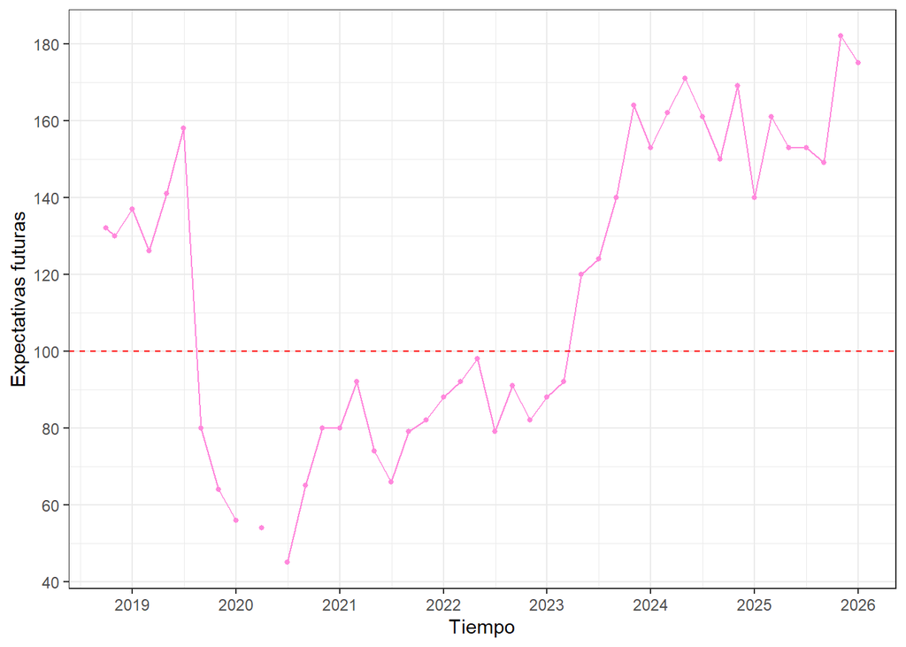

### 1.3.1 ACF de dif1

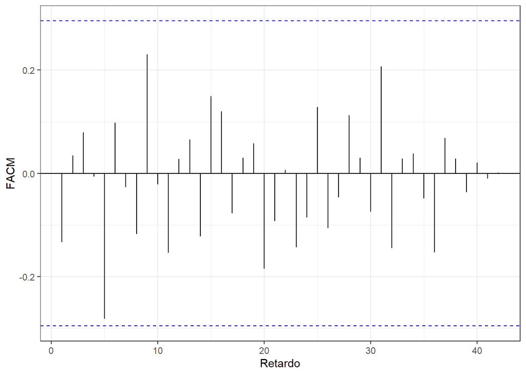

Test Ljung-Box

$H_0) \quad \rho_1 = \dots = \rho_{30} = 0$ ,

$\rho_k:$ coeficiente de autocorrelación de la primer diferencia

```
    Box-Ljung test

data:  pull(drop_na(mutate(tidyr::fill(fill_gaps(d), `Expectativas futuras`, .direction = "down"), dif1 = difference(`Expectativas futuras`)), dif1), dif1)
X-squared = 27.972, df = 30, p-value = 0.5719
```

### 1.3.2 PACF de dif1

[figure not shown]

# 2 Imputacion de las series

Los valores de las series en las fechas marzo 2020 y mayo 2020 son faltantes y deben ser imputados para lograr series de periodicidad regular.

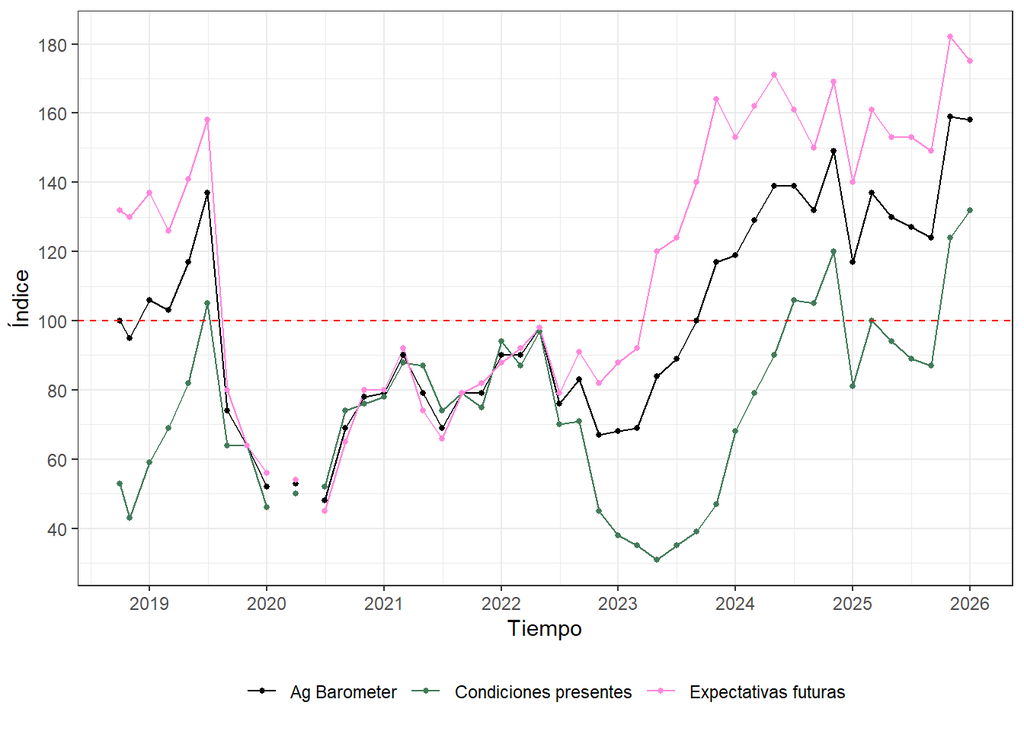

Según las conclusiones de la tesina de Lucía Tamplin y dadas las características de estas tres series analizadas (las tres son paseos aleatorios, visto en la sección 1), el método que más conviene para imputar las dos fechas es *interpolación lineal*.

Las observaciones de octubre 2018 y abril 2020 fueron consideradas a la hora de imputar pero no se las tendrá en cuenta en el resto del trabajo para lograr que las tres series tengan periodicidad regular (bimensual).

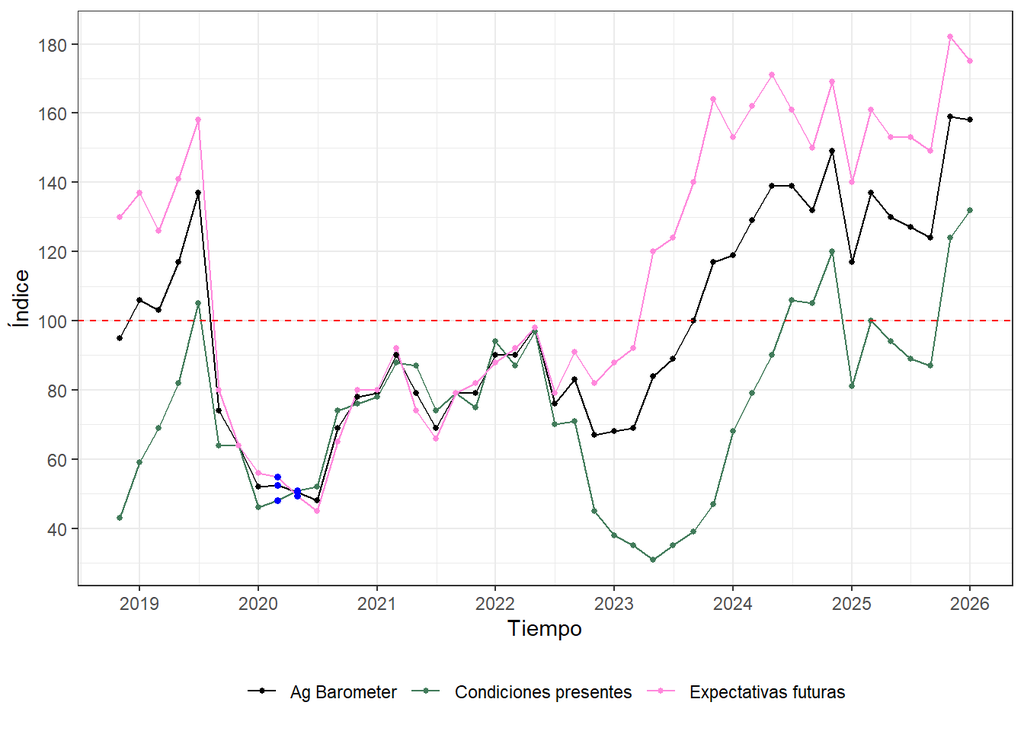

Se obtienen 44 datos para las 3 series.

En resumen,

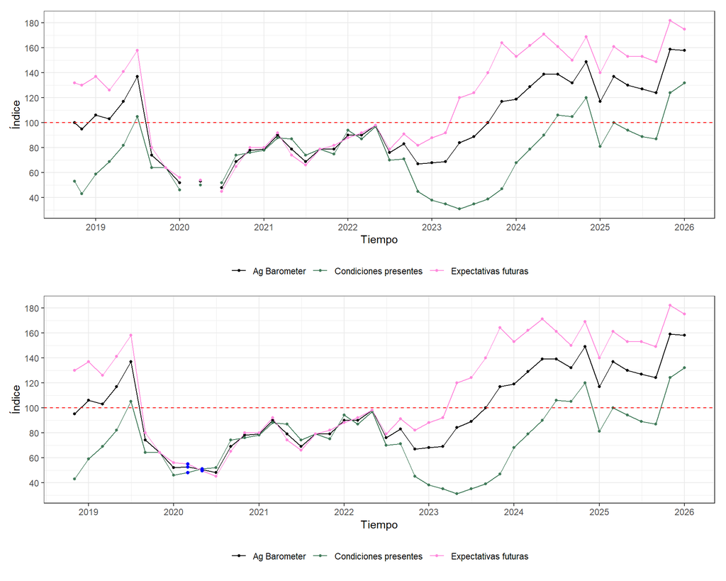